# Group11_CitiBike

Due Feb. 15, 2016

```r
library(plyr)
library(dplyr)
```

```r
library(ggplot2)
library(ggmap)

citiBike <- read.csv("201511-citibike-tripdata.csv")

stations <- unique(subset(citiBike, select = c(start.station.id, start.station.name, start.station.latitude, start.station.longitude)))
nrow(unique(stations))
```

```
## [1] 467
```

```r
routes <- unique(subset(citiBike, select = c(start.station.id, end.station.id)))
nrow(unique(routes))
```

```
## [1] 94400
```

# Patterns in Ride History Data

Identify patterns in the ride history data. Explain these patterns using appropriate visualization. Two potential patterns are (this is an illustrative list, you should formulate your own patterns as well to be explored here):

#### 1. Which stations see the most asymmetric traffic (more arrivals than departures and vice versa)?

```r
endStation<-as.data.frame(table(citiBike$end.station.id))
startStation<-as.data.frame(table(citiBike$start.station.id))
stationData <- merge(startStation, endStation, by="Var1", all=TRUE)
stationData[is.na(stationData)] <- 0
names(stationData) <- c("station.id", "start.freq", "end.freq")
stationData$inTraffic <- stationData$start.freq - stationData$end.freq
stationData$outTraffic <- stationData$end.freq - stationData$start.freq
```

[figure not shown]

```r
outTraffic <- stationData[order(-stationData$outTraffic),]
barplot(outTraffic$outTraffic[outTraffic$outTraffic > 300], main="Bike Stations with Highest Net Outflow of Bikes", names.arg = outTraffic$station.id[outTraffic$outTraffic > 300], xlab = "Station IDs", ylab = "Net Outflow (Bikes)")
```

[figure not shown]

```r
inTraffic <- stationData[order(-stationData$inTraffic),]
barplot(inTraffic$inTraffic[inTraffic$inTraffic > 300], main="Bike Stations with Highest Net Inflow of Bikes", names.arg = inTraffic$station.id[inTraffic$inTraffic > 300], xlab = "Station IDs", ylab = "Net Inflow (Bikes)")
```

#### 2. Which stations originate the longest rides? Does this change as we go through different times of the day?

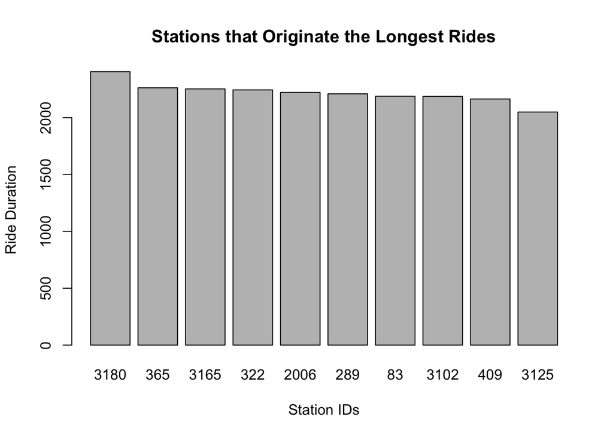

```r
longestRide <- aggregate(citiBike[, 1], list(citiBike$start.station.id), mean)
names(longestRide) <- c("station.id", "mean.trip.duration")
stationData <- merge(stationData, longestRide, by="station.id", all=TRUE)
stationData[is.na(stationData)] <- 0

longestRide <- stationData[order(-stationData$mean.trip.duration),]
barplot(longestRide$mean.trip.duration[longestRide$mean.trip.duration > 2000], main = "Stations that Originate the Longest Rides", names.arg = longestRide$station.id[longestRide$mean.trip.duration > 2000], xlab = "Station IDs", ylab = "Ride Duration")
```

# Dataset Visualization

```
## Using zoom = 13...
```

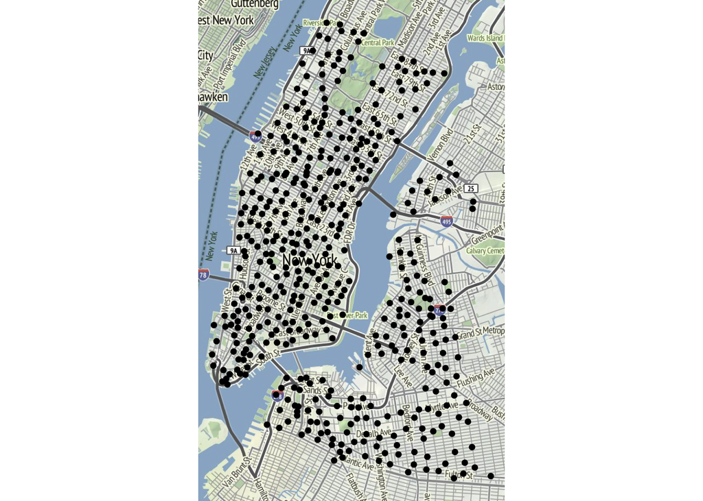

```r
qmplot(start.station.longitude, start.station.latitude, data = stations, maptype = "terrain", source='stamen')
```

```
## Using zoom = 13...
```

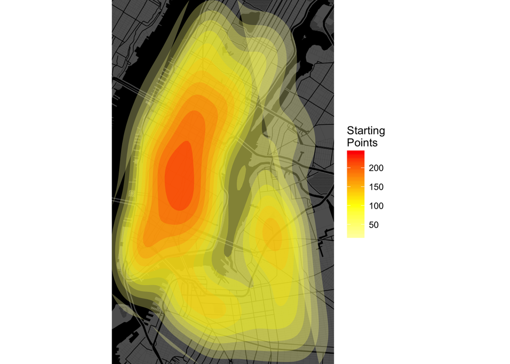

```r
qmplot(start.station.longitude, start.station.latitude, data = stations, maptype = "toner-background", darken = 0.7, geom = "blank", source='stamen') +
  stat_density_2d(aes(fill = ..level..), geom = "polygon", alpha = .3, color = NA) +
  scale_fill_gradient2("Starting\nPoints", low = "white", mid = "yellow", high = "red", midpoint = 100)
```

# Business Issues

#### Stations running out of bikes is a big problem. Client would want to know which stations are candidates for improving bike storage capacity.

```r
# The stations that are start stations the most number of times are likely the best candidates for a higher bike storage capacity
startStationCount <- as.data.frame(table(citiBike$start.station.id))
startStationCount <- startStationCount[order(startStationCount$Freq, decreasing=TRUE),]
head(startStationCount)
```

```
##     Var1  Freq
## 286  519 11267
## 81   293  8810
## 206  435  8268
## 265  497  7740
## 77   285  7175
## 16   151  6172
```

#### Bike maintenance bills are piling up. Client thinks that this is because some bikes are being used a lot more than other bikes. Can you check on this assumption?

#### Client is planning a promotion to increase bike rental by younger folks (age < 25) and tourists (i.e not an annual member). They want to focus on stations that are less used by these target groups. Can you help them identify these stations?

```r
# http://data.fcc.gov/api/block/2010/find?latitude=40.0&longitude=-85
```